← Home

## Sia 分析

如果您对枯燥的数据获取和数据清洗部分不感兴趣，请直接阅读 数据分析；如果您想获取处理好的数据自行分析，请下载 [sia-79701](https://raw.githubusercontent.com/tsai1993/tsai1993.github.io/master/resource/sia-79701.csv.zip)，该数据以 1% 系统取样至 79701 区块。

#### 数据获取

Sia 官网有公开数据，网址为 https://explore.sia.tech/，不过只有当前区块的数据。需要通过查询每一区块的信息获得历史信息。

网站数据由 js 生成的，需要安装 [phantomjs](http://phantomjs.org/) 来提取数据。速度较慢，因此按 1% 系统取样的方法获得数据，即从区块 1 到 2016 年 11 月 25 日的区块 79795 中，每间隔 100 取一个区块。

采用 R 语言的 `rvest` 包抓取数据。

比较奇怪的一点是，区块高度为 35001 的区块信息页面加载很慢，导致该数据缺失。

```r
library(rvest)

# 只需要改动 to 后面的区块高度和间隔 by 即可
Height <- seq(from = 1, to = 79795, by = 100)
URL <- as.vector(paste0("https://explore.sia.tech/block.html?height=", Height))

Sia <- list(length = length(Height))
j <- 1
for(i in URL){
  writeLines(sprintf("var page = require('webpage').create();
                      page.open('%s', function () {
                      console.log(page.content); //page source
                      phantom.exit();
                      });", i), con="scrape.js")
  system("phantomjs scrape.js > scrape.html")
  Web <- read_html("scrape.html")
  Sia[[j]] <- as.vector(html_text(html_nodes(Web, "tr .stats-info")))[1:13]
  print(Sys.time())
  print(i)
  j <- j+1
}

Sia <- t(as.data.frame(Sia))
Sia <- data.frame(Sia)
row.names(Sia) <- Height
names(Sia) <- c("Height", "ID", "Parent","Time", "Difficulty", "Hashrate",
                "Total", "Contracts", "Cost", "Proofs", "MinerID",
                "Address", "Value")

write.csv(Sia, "sia.csv", row.names = F)
```

#### 数据清洗

主要涉及时间格式转换、用正则表达式格式化数据和数据类型转化，还涉及少量的单位转换。

```r
Sia <- read.csv("sia.csv")
Sia_d <- Sia[, c(-2, -3, -11, -12)]

library(stringr)
library(lubridate)

# 时间处理
Time <- as.data.frame(str_split(Sia_d$Time, ",", simplify = T))
Mon <- as.data.frame(str_split(Time$V2, " ", simplify = T))
Mon2 <- match(Mon[[2]], month.abb)
Day <- Mon$V3
Year <- Time$V3
Time <- Time$V1

S_time <- str_c(Year, Mon2, Day, sep = "-")
S_time <- str_c(S_time, Time, sep = " ")
S_time <- ymd_hm(S_time)

Sia_d$Time <- S_time

# 数据格式化和数据转换
Water <- function(x){
  as.numeric(gsub("\\D", "", x))
}

Sia_d$Height <- Water(Sia_d$Height)
Sia_d$Difficulty <- Water(Sia_d$Difficulty)
Sia_d$Hashrate <- Water(Sia_d$Hashrate)

Sia_d$Total <- Water(Sia_d$Total)
Sia_d$Total[1:34] <- Sia_d$Total[1:34] / 10000000
Sia_d$Total <- Sia_d$Total / 10

Sia_d$Contracts <- Water(Sia_d$Contracts)
Sia_d$Cost <- Water(gsub("\\D", "", Sia_d$Cost))
Sia_d$Proofs <- Water(Sia_d$Proofs)
Sia_d$Value <- Water(Sia_d$Value)
```

#### 数据分析

**挖矿难度**

首先看哈希率估计值和挖矿难度。两者其实是一个概念，均表示挖矿难度。Sia 要保证每十分钟产生一个区块，因此每个矿工获得该区块的概率就与全网算力呈反比，哈希率估计值就可以作为矿工投入总量的指标。

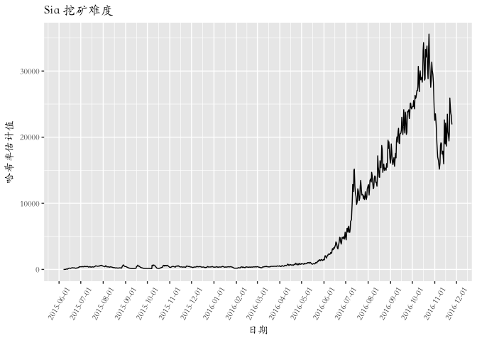

```r
library(ggplot2)
ggplot(Sia_d) +
  geom_line(aes(Time, Hashrate)) +
  scale_x_datetime(date_breaks = "1 month") +
  xlab("日期") +
  ylab("哈希率估计值") +
  ggtitle("Sia 挖矿难度") +
  theme_grey(base_family = "STKaiti") +
  theme(axis.text.x  = element_text(angle = 60, vjust = 0.5))
```

如图，从 2016 年 6 月份开始，挖矿投入持续上升，而且在七月初有大户入场，在十月中下旬达到最高峰。而在十一月上旬，全网算力恢复到七月初的水平，而随后又开始飙升。

这幅图说明了什么，首先，十月中下旬的暴跌说明这个 Sia 挖矿只有有限的几个玩家，而且其中一名挖矿者至少有全网算力的一半以上，这种断崖式下跌是该玩家退场或者中场休息的结果。

随着挖矿难度的上升，矿工套现的压力也越大，因此从七月份以后，Sia Coin 的价格持续下跌。矿工套现离场应该是一个重要因素。

**合约分析**

这幅图的信息最有用吧，从这幅图，我们知道，起码到目前为止，**根本没人在用 Sia 存储**。

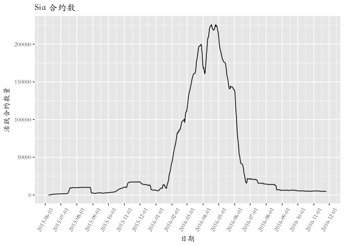

```r
ggplot(Sia_d) +
  geom_line(aes(Time, Contracts)) +
  scale_x_datetime(date_breaks = "1 month") +
  xlab("日期") +
  ylab("活跃合约数量") +
  ggtitle("Sia 合约数") +
  theme_grey(base_family = "STKaiti") +
  theme(axis.text.x  = element_text(angle = 60, vjust = 0.5))
```

如果再看看全部存储合约所消耗的 sc，与上图的合约数量完全不对应。sc 消耗在六月和十月分别有一次跃迁，单在这两个时间里，合约数量却没有显著增长，有可能是有两个大户入场了……

无法获得总文件大小的数据，不过记得之前一直保持在 26T，现在是 27T，看来是有个大户入场的。一个 T 的数据居然也成了大户。整个 Sia 的数量已经达到 207 亿，而存储消耗的 sc 只有 3160 万，千分之一点五而已。

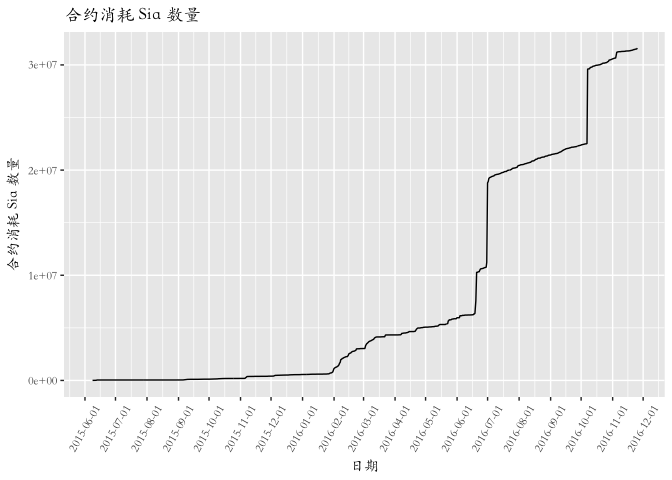

```r
ggplot(Sia_d) +
  geom_line(aes(Time, Cost)) +
  scale_x_datetime(date_breaks = "1 month") +
  xlab("日期") +
  ylab("合约消耗 Sia 数量") +
  ggtitle("合约消耗 Sia 数量") +
  theme_grey(base_family = "STKaiti") +
  theme(axis.text.x  = element_text(angle = 60, vjust = 0.5))
```

#### 总结

之所以做这样一个分析，是想做一个尝试。假想自己是一个 VC，现在你怎样给一个区块链技术公司估值，是否要买入这家公司的股票。鉴于区块链技术与生俱来的数据开放性特征，非常适合这一尝试。

目前 sia 价格异常低，但是在挖矿难度上却有一个反弹，至少说明大佬们还没有放弃投资。

从开发团队的 GitHub 的 [commit](https://github.com/NebulousLabs/Sia/graphs/commit-activity) 情况上看，八月份之后团队对 sia 本身提交补丁的数量显著减少，说明 sia 本身已经比较完善。而八月九月团队主要在开发 [Sia-Ant-Farm](https://github.com/NebulousLabs/Sia-Ant-Farm/graphs/commit-activity)。

以当前价格 0.00172 人民币和当前数量 207 亿计算，总价值 3572 万，而当前合约价格几乎为零（前面分析只占 0.15%）。在短期内，团队还没有死掉的迹象。因此，如果有下一轮融资，可能会有一个短暂的拉升，但是抛售离场得多，拉升空间很小，而且高位时间很短。

对于短期投资者来说，精准预测下一轮融资时间并在最低价位入场是个关键。而对长期投资者来说，前面还是茫茫黑夜。